# Reproducible Reports

## Controlling R code evaluation in notes

We can control how the output from R looks in our rendered documents.

Options are passed to R code by adding a line preceeding R code with the special comment **#+**. We will look at some options later but a useful example is fig.height and fig.width to control figure height and width in the document.

```r
#' Some comments for text.
#+ fig.width=3, fig.height=3
myRandNumbers <- rnorm(100, 10, 2)
hist(myRandNumbers)
```

## Exercise

- Have at the example notebook script “scriptWithNotebookExamples.r” in scripts directory and the html document rendered from it of the same name.
- Open scriptToConvertToNote.r in scripts directory and save as new name.
- Add notes to this script and compile with render() function or through RStudio. Compare changes between the original html and your html.

# Markdown

## Markdown

Under the hood, R is creating an intermediate document in **Markdown** format.

Markdown is a mark up language containing plain text and allowing for conversion to multiple rich text document types.

Common formats markdown renders to are:  
- html - pdf - Word doc

## Markdown

Markdown is often used as an intermediate document in conversion from one type to another.

Github and Sourceforge make use of Markdown syntax in their Readme files and renders these in their webpages.

https://github.com/github/markup/blob/master/README.md

# Markdown Syntax

## Markdown syntax

Markdown uses simple syntax to control text output.

This allows for the inclusion of font styles, text structures, images and code chunks.

Lets look at some simple syntax for markdown to help us understand the R documents output from RStudio.

## New line

Markdown is written as plain text and ignores new lines.

To include a new line in markdown, end the previous line with two spaces.

```
This is my first line.  # the comment here shows the line end
This would be a new line.
This wouldn't be a new line.
```

To start a new paragraph, leave a line of space.

```
This is my first paragraph.

This is my second paragraph
```

## Font emphasis

Emphasis can be added to text in markdown documents using either the **_** or __*__

```r
Italics = _Italics_ or *Italics*
Bold  =  __Bold__ or **Bold**
```

*Italics*  
**Bold**

## Including images

Figures or external images can be used in Markdown documents.  
Files may be local or accessible from http URL.

```
![alt text](imgs/Dist.jpg)
![alt text](https://rockefelleruniversity.github.io//r_course/imgs/Dist.jpg)
```

## Creating headers

Section headers can be added to Markdown documents.

Headers follow the same conventions as used in HTML markup and can implemented at multiple levels of size. Section headers in Markdown are created by using the **#** symbol

```
# Top level section
## Middle level section
### Bottom level section
```

### Rendered Bottom level section

## Lists

Lists can be created in Markdown using the **-** symbol.  
Nested lists be specified with **+** symbol.

```
- First item
- Second item
    + Second item A
    + Second item B
```

My list rendered:

- First item
- Second item
  - Second item A
  - Second item B

## Order lists

Lists can also include ordered numbers.

```
1. First item
2. Second item
    + Second item A
    + Second item B
```

My list rendered:

1. First item
2. Second item
   - Second item A
   - Second item B

## Code chunks

In Markdown, text may be highlighted as if code by placing the text between apostrophes in triplicate: ’’’.

```
_The code used to produce plot was:_
'''
hist(rnorm(100))
'''
```

## Code chunks

In Markdown, text may be highlighted as if code by placing the text between apostrophes in triplicate: ’’’.

```
_The code used to produce plot was:_
'''
hist(rnorm(100))
'''
```

*The code used to produce plot was:*

```
hist(rnorm(100))
```

## HTML links

HTML links can be included in Markdown documents either by simply including address in text or by using **[]** for the phrase to add link to, followed the link in **()**

```
https://rockefelleruniversity.github.io/
[Github site](https://rockefelleruniversity.github.io/)
```

## Page breaks

Markdown allows for the specification of page breaks in your document.  
To specify a page break use 3 or more asterisks or dashes.

[output not shown]

# rMarkdown

## rMarkdown

rMarkdown is a script type used in R to allow for the generation of Markdown from R code. rMarkdown files will typically have the extension **.Rmd**.

rMarkdown allows for the inclusion of Markdown syntax around **chunks** of R code.

The output from running the R code can be tightly controled using rMarkdown, allowing for very neat integration of results with code used to generate them.

## knitr

The **knitr** package is the main route to create documents from **.Rmd** files.

**knitr** was created by Yihui Xie to wrap and clean up issues with other tools to make dynamic documents.

http://yihui.name/knitr/

## Markdown to rMarkdown

The transition from Markdown to rMarkdown is very simple. All Markdown syntax may be included and code to be evaluated in R placed between a special code chunk.

The code chunk containing R code to execute is specified by the inclusion of **{r}** as below.

```
My Markdown **syntax** here
'''{r}
hist(rnorm(1000))
'''
```

My Markdown **syntax** here

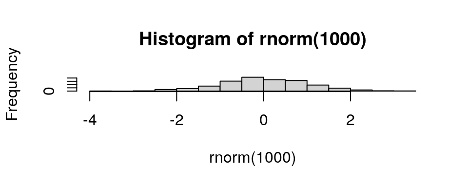

```r
hist(rnorm(1000))
```

## Control code evaluation

Options may be included in the R code chunks.

An important option is to choose whether code will be run or is meant for display only. This can be controlled with the **eval** option. TRUE will evaluate the code.

```
'''{r, eval=F}
hist(rnorm(1000))
'''
```

```r
hist(rnorm(1000))
```

## Control code display

It may be that you wish to report just the results and not include the code used to generate them. This can be controlled with the **echo** argument. TRUE will display the code.

```
'''{r,echo=F}
hist(rnorm(1000))
'''
```

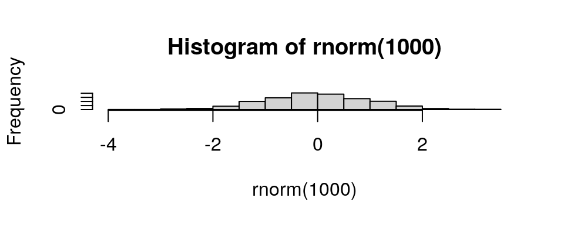

## Messages and warnings

R can produce a lot of output not related to your results. To control whether messages and warnings are reported in the rendered document we can specify the **message** and **warning** arguments.

Loading libraries in rMarkdown is often somewhere you would specify these as FALSE.

```
'''{r,warning=F,message=F}
library(ggplot2)
'''
```

## Control figure output

Control over figure heights and widths can be implemented in rMarkdown using the **fig.width** and **fig.height** arguments. Further control over exact size in rendered document maybe specified with **out.width** and **out.height**.

```
'''{r,fig.width=5,fig.height=5}
hist(rnorm(100))
'''
```

## Automatically tidy code

The code within the **{r}** code block can be reformatted using the formatR package. This can be automatically done when the **tidy** option is specified.

```
'''{r,tidy=T}
        hist(
rnorm(100  )
      )
'''
```

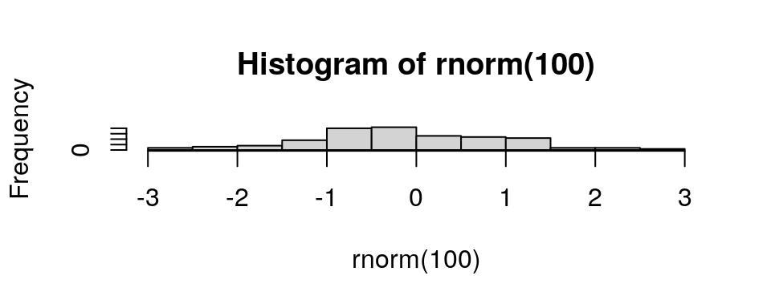

```r
        hist(
rnorm(100  )
)
```

## Print output with code

The code within the **{r}** code block will by default appear in a separate block to results output. To force code and output to appear in the same block the **collapse** option should be specified.

```
'''{r,collapse=T}
temp <- rnorm(10)
temp
'''
```

```r
temp <- rnorm(10)
temp
##  [1]  0.3609556  0.7084886  0.3073245  1.0111966  0.4223198 -0.7540375
##  [7] -0.5321262  0.1298639  1.0131601  1.7044641
```

## Inserting tables

The results of printing data frames or matrices in the console aren’t neat.

We can insert HTML tables into Markdown by setting the **results** option to **asis** and using the knitr function **kable()**.

```
'''{r,results='asis'}
temp <- rnorm(10)
temp2 <- rnorm(10)
dfExample <- cbind(temp,temp2)
kable(dfExample)
'''
```

## Evaluating code in the md

It may be useful to report the results of R within the block of Markdown. This can be done adding the code to evalulate within **‘r’**

```
Here is some freeform _markdown_ and the first result
from an rnorm call is 'r rnorm(3)[1]', followed by some
more free form text.
```

Here is some freeform *markdown* and the first result from an rnorm call is -0.2133819, followed by some more free form text.

## cache

Some operations may take a significant time or resource to compute.

The **cache** argument may be used to save the results in the current working directory. This code chunk will import the results in future document compilations and save computation time.

```
'''{r,cache=TRUE}
x <- sample(1000,10^8,replace=T)
length(x)
'''
```

## Saving a plot through rMarkdown

It is possible to save plots in your HTML reports by just right-clicking on them. It is sometimes easier to directly create seperate files with your plots. When we reviewed plotting we saw how to export plots, but rMarkdown has in-built system for figure output.

You can control the plot dimensions, the name, file type and path in which they will be saved. If you export multiple plots from a single chunk, they will have the same name, but they will be appended with a number.

```
'''{r my_plot_title, fig.width=5, fig.height=5, fig.path='figures/', dev=c('png','pdf')}
plot(1:10)
'''
```

## YAML in rMarkdown

In rMarkdown the options for document processing are stored in YAML format at the top of the document.

```
title: "Untitled"
author: "tcarroll"
date: "21 November 2014"
output: html_document
```

## Controlling output type

The **output** YAML option specifies the document type to be produced.

```
output: html_document
```

```
output: pdf_document
```

```
output: word_document
```

```
output: md_document
```

## Figure options in YAML

Global default options for figure sizes and devices used can be set within the YAML metadata.

```
output:
  html_document:
    fig_width: 7
    fig_height: 6
```

## Adding styles

Styles for HTML can be applied using the **theme** option and syntax highlighting styles control by the **highlight** option.

```
output:
  html_document:
    theme: journal
    highlight: espresso
```

For a full list of theme options see - http://rmarkdown.rstudio.com/html_document_format.html

## Additional styles

```
output:
  html_document:
    css: style.css
```

Custom styles can also be applied to rMarkdown documents using CSS style files and the **css** option.

## Using Rstudio

Lets see how to do this in RStudio.

**File -> New File -> R Markdown**

## Resources

http://yihui.name/knitr/  
http://rmarkdown.rstudio.com/  
http://rcharts.io/  
http://rstudio.github.io/packrat/

## Exercises

- Open up markdownExampleDefaultStyles.Rmd and markdownExample.Rmd in the scripts directory. Have a look at the rMarkdown examples here and the resulting output html files.

Example HTML Default style.  
Example HTML with extra style.

- Open scriptToConvertToRMarkdown.r in scripts directory and save as new name.
- Convert this script to an Rmarkdown document using the render() function or inside RStudio.

# Contact

Any suggestions, comments, edits or questions (about content or the slides themselves) please reach out to our [GitHub](https://github.com/RockefellerUniversity/Reproducible_R/issues) and raise an issue.